# MANOVA

Bartlett’s test is sensitive to departures from normality. That is, if the samples come from non-normal distributions, then Bartlett’s test may simply be testing for non-normality.

```r
bartlett.test(SWIMresCAT~cat)
```

```
    Bartlett test of homogeneity of variances

data:  SWIMresCAT by cat
Bartlett's K-squared = 3.5946, df = 2, p-value = 0.1657
```

```r
bartlett.test(BIKEresCAT~cat)
```

```
    Bartlett test of homogeneity of variances

data:  BIKEresCAT by cat
Bartlett's K-squared = 5.6426, df = 2, p-value = 0.05953
```

```r
bartlett.test(RUNresCAT~cat)
```

```
    Bartlett test of homogeneity of variances

data:  RUNresCAT by cat
Bartlett's K-squared = 1.5297, df = 2, p-value = 0.4654
```

```r
bartlett.test(SWIMresGEN~gender)
```

```
    Bartlett test of homogeneity of variances

data:  SWIMresGEN by gender
Bartlett's K-squared = 5.5283, df = 1, p-value = 0.01871
```

```r
bartlett.test(BIKEresGEN~gender)
```

```
    Bartlett test of homogeneity of variances

data:  BIKEresGEN by gender
Bartlett's K-squared = 2.6913, df = 1, p-value = 0.1009
```

```r
bartlett.test(RUNresGEN~gender)
```

```
    Bartlett test of homogeneity of variances

data:  RUNresGEN by gender
Bartlett's K-squared = 0.44856, df = 1, p-value = 0.503
```

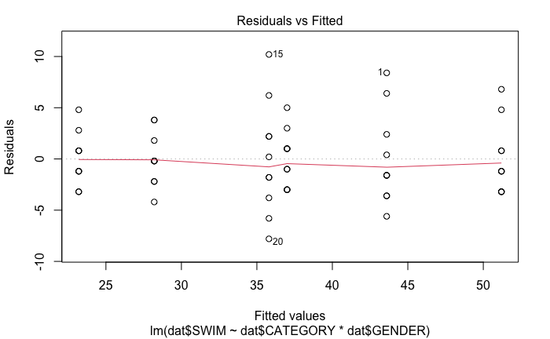

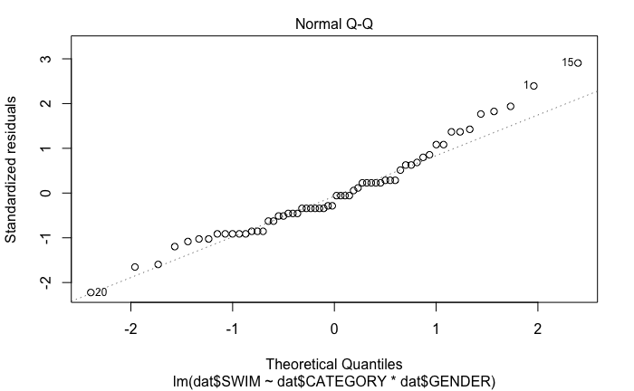

```
hat values (leverages) are all = 0.1
 and there are no factor predictors; no plot no. 5
```

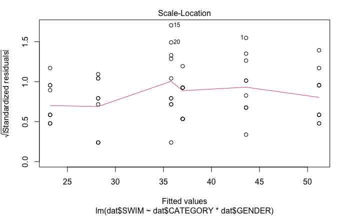

```r
plot(lm(dat$SWIM~dat$CATEGORY*dat$GENDER))
```

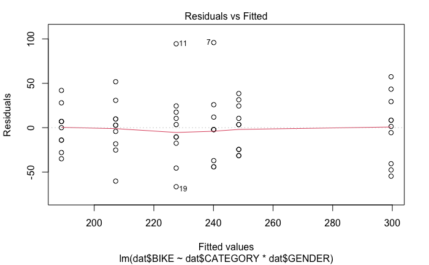

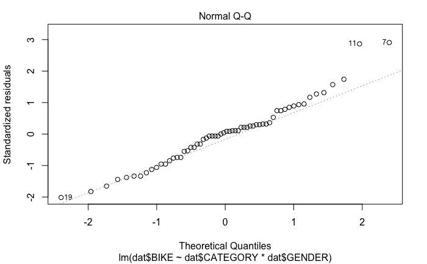

```
hat values (leverages) are all = 0.1
 and there are no factor predictors; no plot no. 5
```

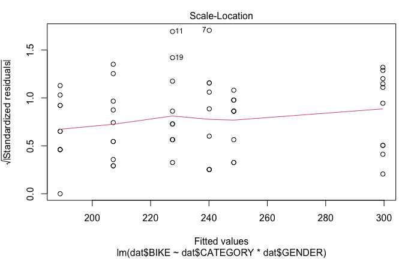

```r
plot(lm(dat$BIKE~dat$CATEGORY*dat$GENDER))
```

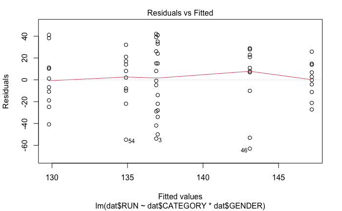

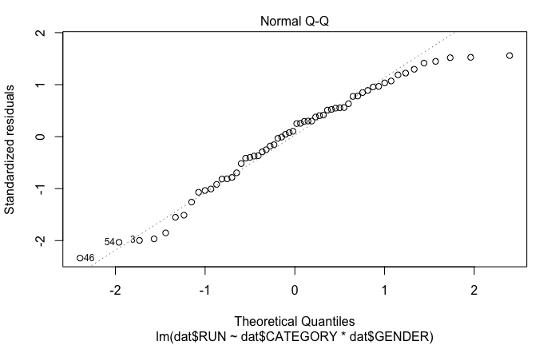

```
hat values (leverages) are all = 0.1
 and there are no factor predictors; no plot no. 5
```

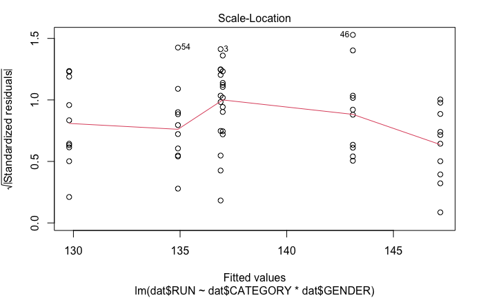

```r
plot(lm(dat$RUN~dat$CATEGORY*dat$GENDER))
```

# Run the MANOVA

```r
output <- manova(times~gender*cat)

summary.aov(output)
```

```
 Response SWIM :
            Df Sum Sq Mean Sq  F value    Pr(>F)
gender       1   24.1   24.07   1.7591    0.1903
cat          2 4709.2 2354.60 172.1012 < 2.2e-16 ***
gender:cat   2  396.9  198.47  14.5062 9.073e-06 ***
Residuals   54  738.8   13.68
---
Signif. codes:  0 ‘***’ 0.001 ‘**’ 0.01 ‘*’ 0.05 ‘.’ 0.1 ‘ ’ 1

 Response BIKE :
            Df Sum Sq Mean Sq F value    Pr(>F)
gender       1   6469  6468.8  5.3476  0.024591 *
cat          2  51697 25848.3 21.3682 1.458e-07 ***
gender:cat   2  15094  7546.8  6.2388  0.003651 **
Residuals   54  65322  1209.7
---
Signif. codes:  0 ‘***’ 0.001 ‘**’ 0.01 ‘*’ 0.05 ‘.’ 0.1 ‘ ’ 1

 Response RUN :
            Df Sum Sq Mean Sq F value Pr(>F)
gender       1      2    2.02  0.0025 0.9604
cat          2   1682  840.80  1.0376 0.3612
gender:cat   2    212  106.07  0.1309 0.8776
Residuals   54  43756  810.29
```

Pillai’s trace is a test statistic produced by a MANOVA. It is a value that ranges from 0 to 1.

The closer Pillai’s trace is to 1, the stronger the evidence that the explanatory variable has a statistically significant effect on the values of the response variables.

Pillai’s trace, often denoted V, is calculated as:

$V = trace(H(H+E)^{-1})$

where:

H: The hypothesis sum of squares and cross products matrix E: The error sum of squares and cross products matrix When performing a MANOVA, most statistical software will use Pillai’s trace to calculate a rough approximation to an F-statistic along with a corresponding p-value.

If this p-value is less than some significance level (i.e. α = .05) then we reject the null hypothesis of the MANOVA and conclude that the explanatory variable has a significant effect on the values of the response variables.

```r
summary(output, test="Wilks")
```

```
           Df   Wilks approx F num Df den Df    Pr(>F)
gender      1 0.90547   1.8095      3     52 0.1568890
cat         2 0.12952  30.8289      6    104 < 2.2e-16 ***
gender:cat  2 0.62497   4.5923      6    104 0.0003562 ***
Residuals  54
---
Signif. codes:  0 ‘***’ 0.001 ‘**’ 0.01 ‘*’ 0.05 ‘.’ 0.1 ‘ ’ 1
```

```r
summary(output, test="Pillai")
```

```
           Df  Pillai approx F num Df den Df    Pr(>F)
gender      1 0.09453   1.8095      3     52   0.15689
cat         2 0.90048  14.4686      6    106 5.338e-12 ***
gender:cat  2 0.37636   4.0952      6    106   0.00098 ***
Residuals  54
---
Signif. codes:  0 ‘***’ 0.001 ‘**’ 0.01 ‘*’ 0.05 ‘.’ 0.1 ‘ ’ 1
```

```r
summary(output, test="Hotelling")
```

```
           Df Hotelling-Lawley approx F num Df den Df    Pr(>F)
gender      1           0.1044    1.810      3     52 0.1568890
cat         2           6.4889   55.156      6    102 < 2.2e-16 ***
gender:cat  2           0.5979    5.083      6    102 0.0001335 ***
Residuals  54
---
Signif. codes:  0 ‘***’ 0.001 ‘**’ 0.01 ‘*’ 0.05 ‘.’ 0.1 ‘ ’ 1
```